# Building Propensity Score Models

Lucy D’Agostino McGowan

## Observational Studies

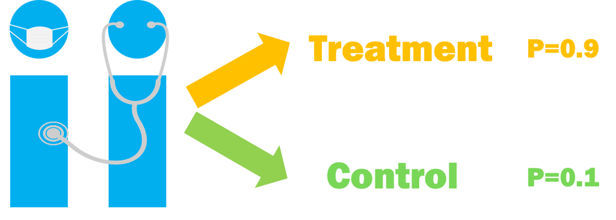

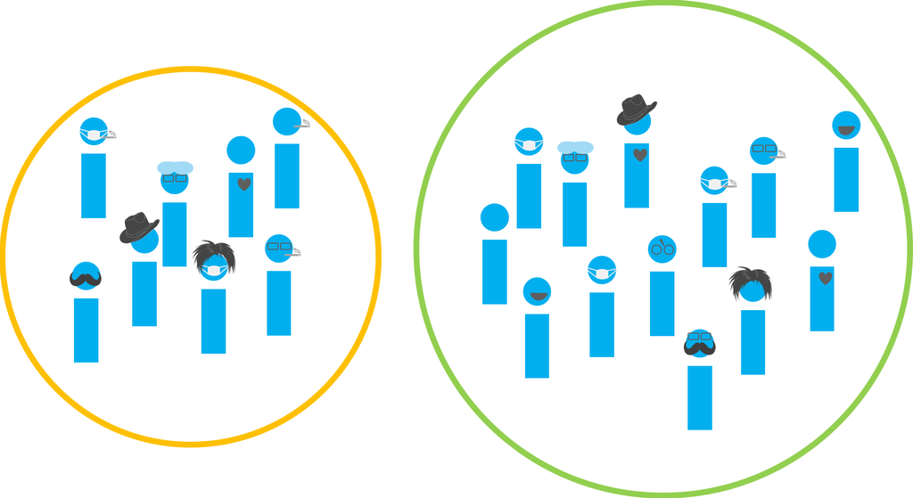

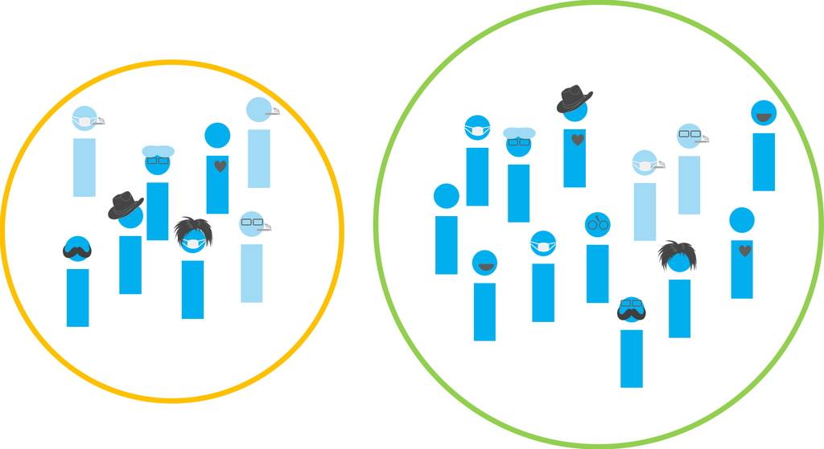

## Confounding

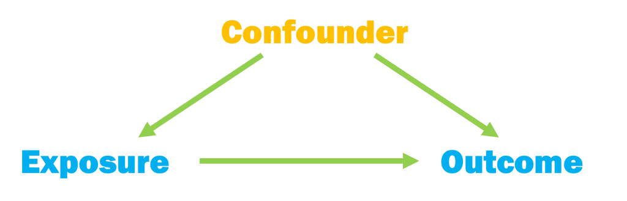

## Confounding

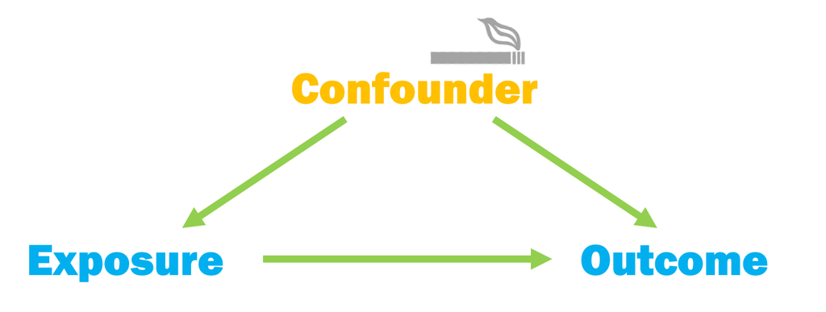

## Propensity scores

Rosenbaum and Rubin showed in observational studies, conditioning on **propensity scores** can lead to unbiased estimates of the exposure effect

1. There are no unmeasured confounders
2. Every subject has a nonzero probability of receiving either exposure

## Propensity scores

- Fit a **logistic regression** predicting exposure using known covariates

$$Pr(exposure = 1) = \frac{1}{1+\exp(-X\beta)}$$

- Each individuals’ predicted values are the **propensity scores**

## Propensity scores

```r
library(tidyverse)
library(broom)
```

## Propensity scores

```r
glm(exposure ~ confounder_1 + confounder_2 + confounder_3 + ...,
    data = df,
    family = binomial())
```

## Propensity scores

```r
glm(exposure ~ confounder_1 + confounder_2 + confounder_3 + ...,
    data = df,
    family = binomial()) |>
  augment(type.predict = "response", data = df)
```

## Propensity scores

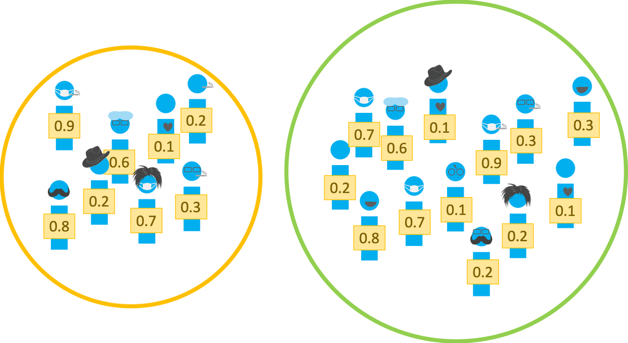

## Example

[figure not shown]

Photo by Anna [CC-BY-SA-4.0](https://creativecommons.org/licenses/by-sa/4.0/deed.en)

Historically, guests who stayed in a Walt Disney World resort hotel were able to access the park during “Extra Magic Hours” during which the park was closed to all other guests.

These extra hours could be in the morning or evening.

The Seven Dwarfs Mine Train is a ride at Walt Disney World’s Magic Kingdom. Typically, each day Magic Kingdom may or may not be selected to have these “Extra Magic Hours”.

**We are interested in examining the relationship between whether there were “Extra Magic Hours” in the morning and the average wait time for the Seven Dwarfs Mine Train the same day between 9am and 10am.**

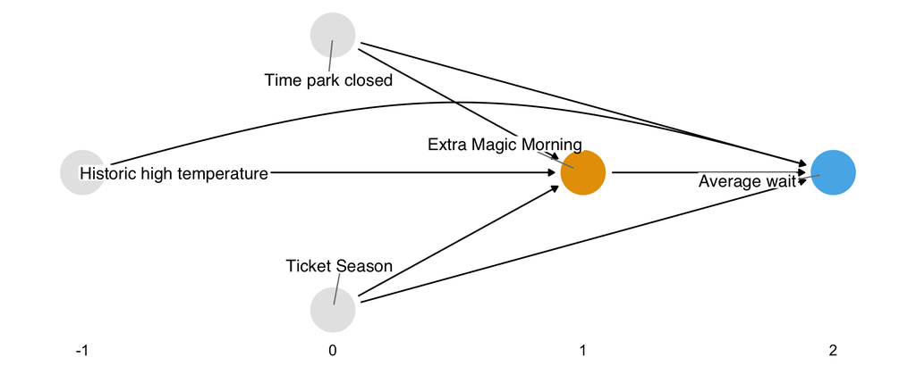

## Propensity scores

Matching

Weighting

Stratification

Direct Adjustment

…

## Estimands

Greifer, N., & Stuart, E. A. (2021). Choosing the estimand when matching or weighting in observational studies. arXiv preprint arXiv:2106.10577. See also [Choosing Estimands](https://www.r-causal.org/chapters/10-estimands) in our book.

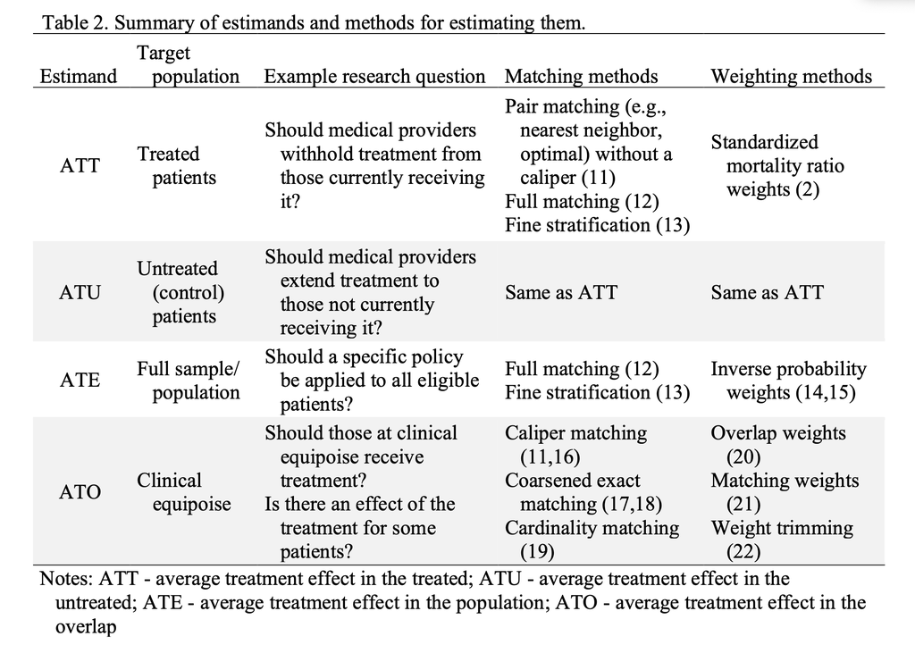

## Propensity scores

**Matching**

Weighting

Stratification

Direct Adjustment

…

## Target estimands

**Average Treatment Effect (ATE)**

$$\tau = E[Y(1) - Y(0)]$$

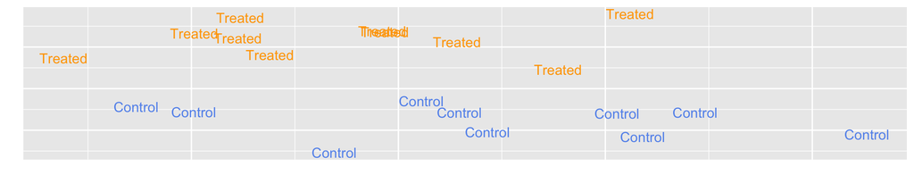

## Target estimands

**Average Treatment Effect among the Treated (ATT)**

$$\tau = E[Y(1) - Y(0) | X = 1]$$

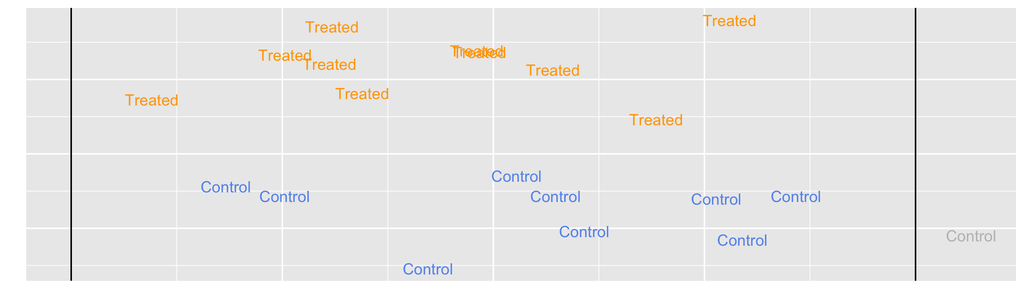

## Matching in R (ATT)

```r
library(MatchIt)
m <- matchit(qsmk ~ sex +
    race + age + I(age^2) + education +
    smokeintensity + I(smokeintensity^2) +
    smokeyrs + I(smokeyrs^2) + exercise + active +
    wt71 + I(wt71^2),
  data = nhefs_complete)
m
```

```
A `matchit` object
 - method: 1:1 nearest neighbor matching without replacement
 - distance: Propensity score
             - estimated with logistic regression
 - number of obs.: 1566 (original), 806 (matched)
 - target estimand: ATT
 - covariates: sex, race, age, I(age^2), education, smokeintensity, I(smokeintensity^2), smokeyrs, I(smokeyrs^2), exercise, active, wt71, I(wt71^2)
```

## Matching in R (ATT)

```r
matched_data <- get_matches(m, id = "i")
glimpse(matched_data)
```

```
Rows: 806
Columns: 71
$ i                 <chr> "11", "1220", "15", "1082", "18"…
$ subclass          <fct> 1, 1, 2, 2, 3, 3, 4, 4, 5, 5, 6,…
$ weights           <dbl> 1, 1, 1, 1, 1, 1, 1, 1, 1, 1, 1,…
$ seqn              <dbl> 428, 23045, 446, 22294, 596, 140…
$ qsmk              <dbl> 1, 0, 1, 0, 1, 0, 1, 0, 1, 0, 1,…
$ death             <dbl> 0, 0, 1, 0, 0, 0, 0, 0, 0, 0, 1,…
$ yrdth             <dbl> NA, NA, 88, NA, NA, NA, NA, NA, …
$ modth             <dbl> NA, NA, 1, NA, NA, NA, NA, NA, N…
$ dadth             <dbl> NA, NA, 3, NA, NA, NA, NA, NA, N…
$ sbp               <dbl> 135, 159, 141, 113, 151, NA, 125…
$ dbp               <dbl> 89, 91, 79, 73, 80, NA, 71, 85, …
$ sex               <fct> 0, 1, 1, 0, 1, 0, 1, 1, 0, 1, 0,…
$ age               <dbl> 43, 49, 71, 36, 48, 51, 56, 40, …
```

[output cut: 58 more lines]

## Target estimands

**Average Treatment Effect among the Controls (ATC)**

$$\tau = E[Y(1) - Y(0) | X = 0]$$

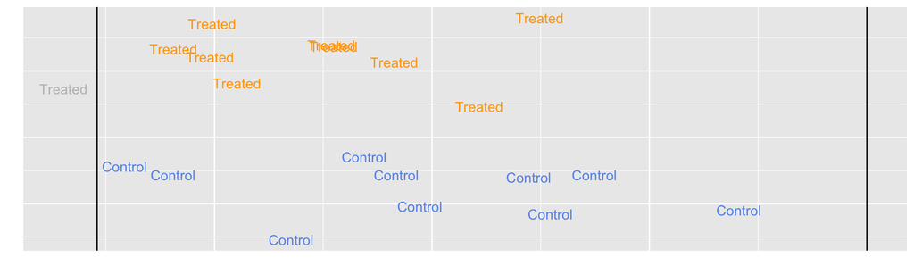

## Matching in R (ATC)

```r
library(MatchIt)
m <- matchit(qsmk ~ sex +
    race + age + I(age^2) + education +
    smokeintensity + I(smokeintensity^2) +
    smokeyrs + I(smokeyrs^2) + exercise + active +
    wt71 + I(wt71^2),
  data = nhefs_complete,
  estimand = "ATC")
m
```

```
A `matchit` object
 - method: 1:1 nearest neighbor matching without replacement
 - distance: Propensity score
             - estimated with logistic regression
 - number of obs.: 1566 (original), 806 (matched)
 - target estimand: ATC
 - covariates: sex, race, age, I(age^2), education, smokeintensity, I(smokeintensity^2), smokeyrs, I(smokeyrs^2), exercise, active, wt71, I(wt71^2)
```

## Target estimands

**Average Treatment Effect among the Matched (ATM)**

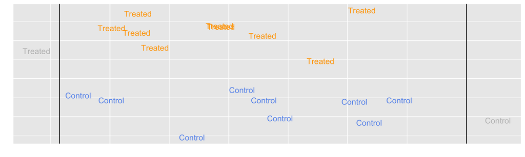

## Matching in R (ATM)

```r
library(MatchIt)
m <- matchit(qsmk ~ sex +
    race + age + I(age^2) + education +
    smokeintensity + I(smokeintensity^2) +
    smokeyrs + I(smokeyrs^2) + exercise + active +
    wt71 + I(wt71^2),
  data = nhefs_complete,
  link = "linear.logit",
  caliper = 0.1)
m
```

## Matching in R (ATM)

```
A `matchit` object
 - method: 1:1 nearest neighbor matching without replacement
 - distance: Propensity score [caliper]

             - estimated with logistic regression and linearized
 - caliper: <distance> (0.063)
 - number of obs.: 1566 (original), 780 (matched)
 - target estimand: ATT
 - covariates: sex, race, age, I(age^2), education, smokeintensity, I(smokeintensity^2), smokeyrs, I(smokeyrs^2), exercise, active, wt71, I(wt71^2)
```

## Matching in R (ATM)

```r
matched_data <- get_matches(m, id = "i")
glimpse(matched_data)
```

```
Rows: 780
Columns: 71
$ i                 <chr> "11", "1220", "15", "1082", "18"…
$ subclass          <fct> 1, 1, 2, 2, 3, 3, 4, 4, 5, 5, 6,…
$ weights           <dbl> 1, 1, 1, 1, 1, 1, 1, 1, 1, 1, 1,…
$ seqn              <dbl> 428, 23045, 446, 22294, 596, 140…
$ qsmk              <dbl> 1, 0, 1, 0, 1, 0, 1, 0, 1, 0, 1,…
$ death             <dbl> 0, 0, 1, 0, 0, 0, 0, 0, 0, 0, 1,…
$ yrdth             <dbl> NA, NA, 88, NA, NA, NA, NA, NA, …
$ modth             <dbl> NA, NA, 1, NA, NA, NA, NA, NA, N…
$ dadth             <dbl> NA, NA, 3, NA, NA, NA, NA, NA, N…
$ sbp               <dbl> 135, 159, 141, 113, 151, NA, 125…
$ dbp               <dbl> 89, 91, 79, 73, 80, NA, 71, 85, …
$ sex               <fct> 0, 1, 1, 0, 1, 0, 1, 1, 0, 1, 1,…
$ age               <dbl> 43, 49, 71, 36, 48, 51, 56, 40, …
```

[output cut: 58 more lines]

## Propensity scores

Matching

**Weighting**

Stratification

Direct Adjustment

…

## Target estimands: ATE

Average Treatment Effect (ATE)

$$\Large w_{ATE} = \frac{X_i}{p_i} + \frac{1-X_i}{1 - p_i}$$

```r
(X / p) + ((1 - X) / (1 - p))
```

## Target estimands: ATT & ATC

Average Treatment Effect Among the Treated (ATT)
$$\Large w_{ATT} = \frac{p_i X_i}{p_i} + \frac{p_i (1-X_i)}{1-p_i}$$

```r
((p * X) / p) + ((p * (1 - X)) / (1 - p))
```

## Target estimands: ATT & ATC

Average Treatment Effect Among the Controls (ATC)
$$\Large w_{ATC} = \frac{(1-p_i)X_i}{p_i} + \frac{(1-p_i)(1-X_i)}{(1-p_i)}$$

```r
(((1 - p) * X) / p) + (((1 - p) * (1 - X)) / (1 - p))
```

## Target estimands: ATM & ATO

Average Treatment Effect Among the Evenly Matchable (ATM)
$$\Large w_{ATM} = \frac{\min \{p_i, 1-p_i\}}{X_ip_i + (1-X_i)(1-p_i)}$$

```r
pmin(p, 1 - p) / (X * p + (1 - X) * (1 - p))
```

## Target estimands: ATM & ATO

Average Treatment Effect Among the Overlap Population
$$\Large w_{ATO} = (1-p_i)X_i + p_i(1-X_i)$$

```r
(1 - p) * X + p * (1 - X)
```

## Histogram of propensity scores

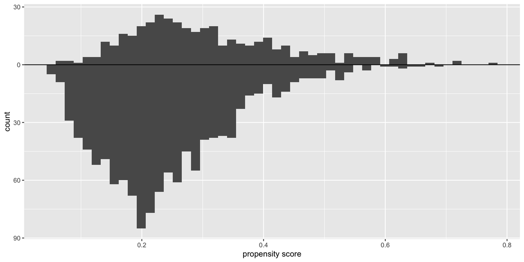

## ATE

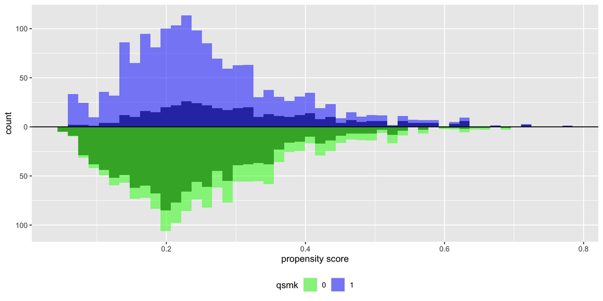

## ATT

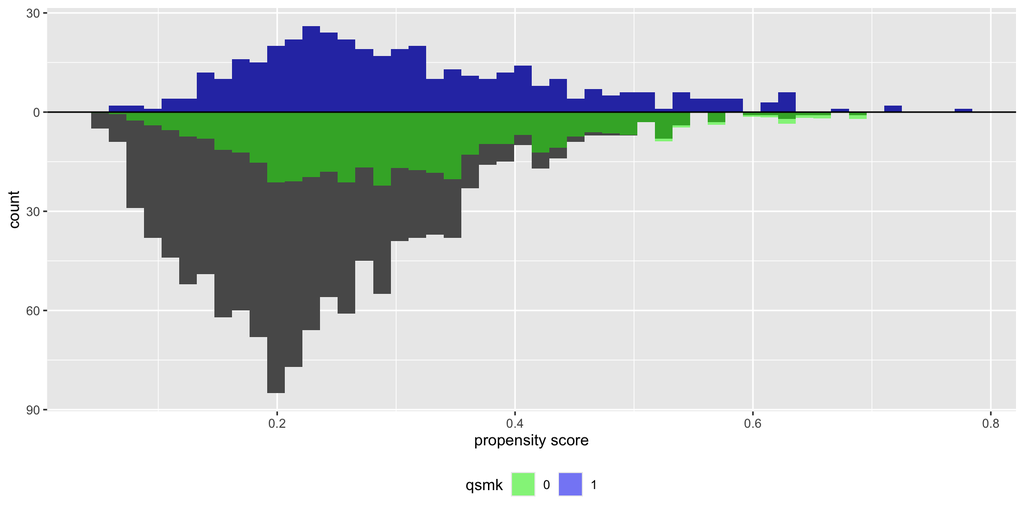

## ATC

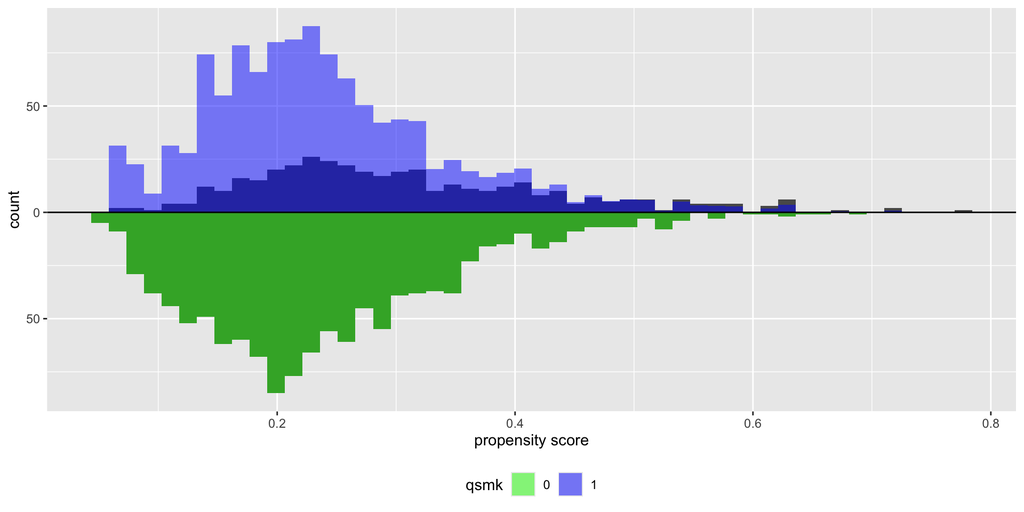

## ATM

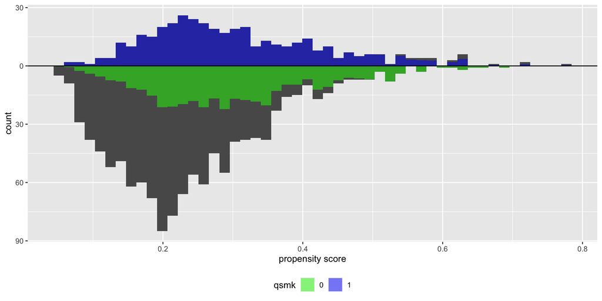

## ATO

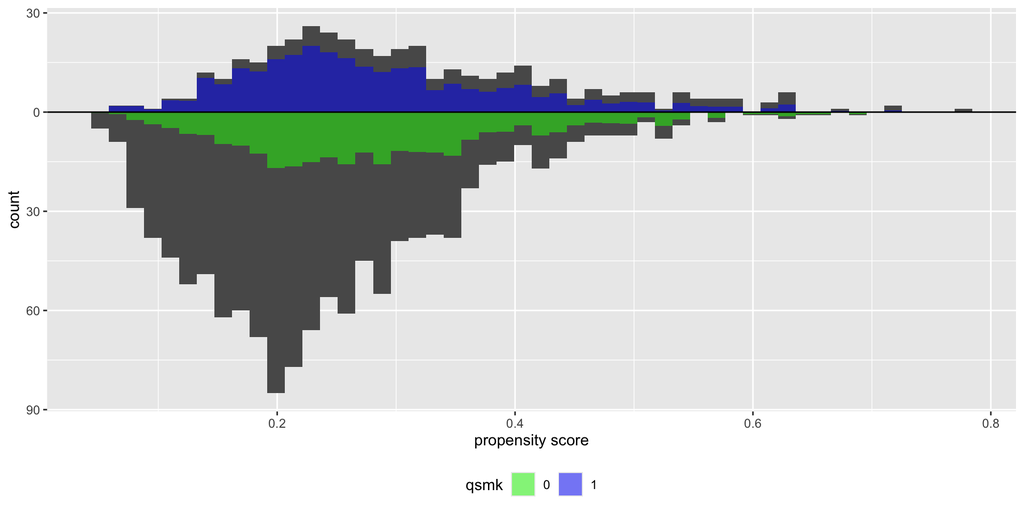

## ATE in R

[figure not shown]

Average Treatment Effect (ATE) $w_{ATE} = \frac{X_i}{p_i} + \frac{1-X_i}{1 - p_i}$

```r
library(propensity)
df <- propensity_model |>
  augment(type.predict = "response", data = nhefs_complete) |>
  mutate(w_ate = wt_ate(.fitted, qsmk))
```